# Análisis de emociones y sentimientos de preguntas abiertas en encuestas

# DATA MINING

Carga de paquetes:

```r
pacman::p_load(stringr,haven,dplyr,ggplot2,tidytext,sjlabelled,quanteda,quanteda.textstats,quanteda.textplots,textdata,tidyr)
```

Carga de datos:

```r
datos <- read_sav("Datos.sav")

# Eliminar los labels del nombre de las columnas
datos <- remove_all_labels(datos)
```

Hay 2 variables: REGISTRO y RESPUESTA.

- REGISTRO es el ID de cada dato, pero. Pese a que estos datos son un identificador (REGISTRO), se decide prescindir del identificador porque añade complejidad innecesaria y se crea uno nuevo, al que denominamos “datosID”.
- RESPUESTA es la respuesta que ha dado el entrevistado a la pregunta abierta.

```r
datos <- datos %>% mutate(datosID=row_number())
datos <- datos[,-1] # Se elimina ESTUDIO
datos <- datos[, c(ncol(datos), 1:(ncol(datos)-1))]
colnames(datos) <- c("datosID", "RESPUESTA")

summary(datos)
```

```
    datosID     RESPUESTA
 Min.   :  1   Length:553
 1st Qu.:139   Class :character
 Median :277   Mode  :character
 Mean   :277
 3rd Qu.:415
 Max.   :553
```

## Preprocesamiento

Es la variable RESPUESTA la que incluye la información a analizar (texto).

En primer lugar, se eliminan posibles nombres de usuario del texto puesto que no aportan información relevante (además de por motivos de privacidad). Aunque tal vez en nuestros datos esto no se dé.

```r
#Eliminamos un posible nombre de usuario del texto
datos$RESPUESTA <- datos$RESPUESTA %>%
  str_replace_all(pattern = "@\\w+", replacement = "")

#En este código, @\\w+ es una expresión regular que busca el símbolo @ seguido de uno o más caracteres alfanuméricos, que corresponde a una mención de usuario típica en Twitter (por ejemplo.

#La función str_replace_all reemplaza todas las ocurrencias de este patrón en el texto con un string vacío, #efectivamente eliminando las menciones.
```

A continuación, se eliminan modifican aquellas palabras que sean q o k por que, es decir, la palabra completa.

```r
datos$RESPUESTA <- gsub("\\b(k|q)\\b", "que", datos$RESPUESTA, ignore.case = TRUE)
```

Cambio de encuestas por encuesta

```r
datos$RESPUESTA <- gsub("\\bencuestas\\b", "encuesta", datos$RESPUESTA, ignore.case = TRUE)
```

Cambio de privadas por privada

```r
datos$RESPUESTA <- gsub("\\privadas\\b", "privada", datos$RESPUESTA, ignore.case = TRUE)
```

Uso de unnest_tokens()

```r
tidydatos <- datos %>% unnest_tokens(palabra,RESPUESTA,strip_punct=TRUE,strip_numeric = TRUE) %>%
  anti_join(get_stopwords(language = "es"),by = c("palabra"="word"))
```

Tal y como se había mencionado, también se crea la estructura de texto corpus mediante la función corpus().

### Corpus

```r
corpus_datos <- corpus(datos, docid_field = "datosID",text_field = "RESPUESTA")
```

A continuación, se realizan una serie de operaciones encadenadas para convertir el corpus en una matriz de documentos-términos (DTM). A partir del corpus anteriormente creado la función tokens() divide cada documento en el corpus en tokens. Luego, la función dfm convierte los tokens en una matriz de documentos-términos. La matriz resultante es almacenada en el objeto dtm_datos.

### Tokenizar

En el proceso de tokenización incluímos las tareas de pre-procesamiento

```r
dtm_datos <- corpus_datos |> tokens() |> dfm()
```

A continuación, se presenta un gráfico con los 20 términos más frecuentes **antes** de incluir las tareas de pre-procesamiento.

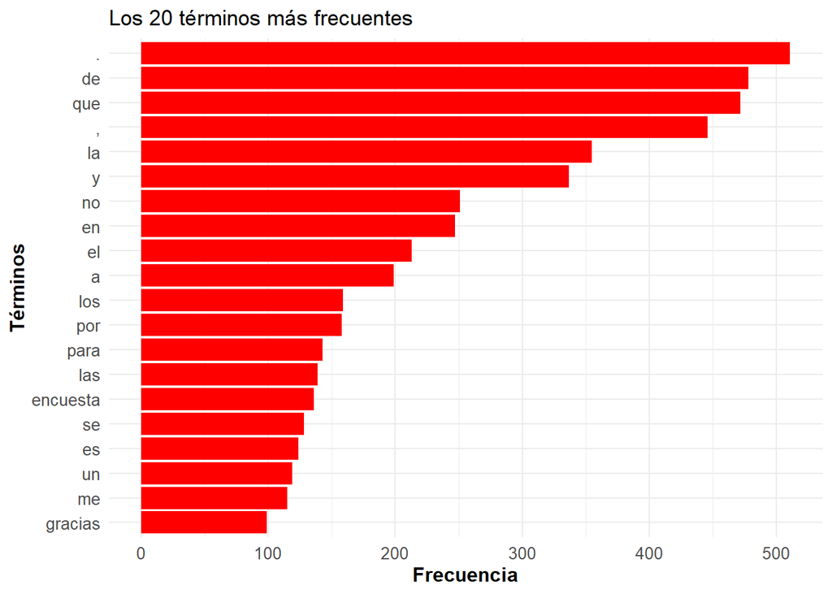

```r
top_20 <- textstat_frequency(dtm_datos, n = 20)

ggplot(top_20, aes(x = reorder(feature, frequency), y = frequency)) +
  geom_col(fill = "red") +
  coord_flip() +
  labs(title = "Los 20 términos más frecuentes",
       x = "Términos",
       y = "Frecuencia") +
  theme_minimal() +
  theme(axis.text = element_text(size = 10),
        axis.title = element_text(size = 12, face = "bold"))
```

Tal y como se puede apreciar, si no se incluyen las tareas de preprocesamiento en la tokenización, los términos más frecuentes son signos de puntuación, preposiciones, conjunciones…

A continuación, se efectúa el proceso de tokenización junto con las tareas de pre-procesamiento. Esto incluye operaciones para limitar texto como:

- remove_punct = TRUE: elimina la puntuación de los tokens,
- remove_numbers = TRUE: elimina los números de los tokens,
- remove_symbols = TRUE: elimina símbolos especiales de los tokens,
- remove_url = TRUE: elimina las URLs de los tokens.

### Tokenizar con limpieza

```r
# Paquete quanteda
dtm_datos <- corpus_datos |> tokens(remove_punct=TRUE,
                                      remove_numbers =TRUE,
                                      remove_symbols = TRUE,
                                      remove_url = TRUE) |>
  tokens_tolower() |>
  tokens_remove(stopwords("es")) |> # El stopwords de quanteda
  dfm()
```

Se ha usado el stopwords de quanteda

**Frecuencia de términos** A continuación, se pueden observar las 20 palabras más frecuentes después del preprocesamiento y que constituyen el inicio de nuestro análisis descriptivo

**YA LIMPIO**

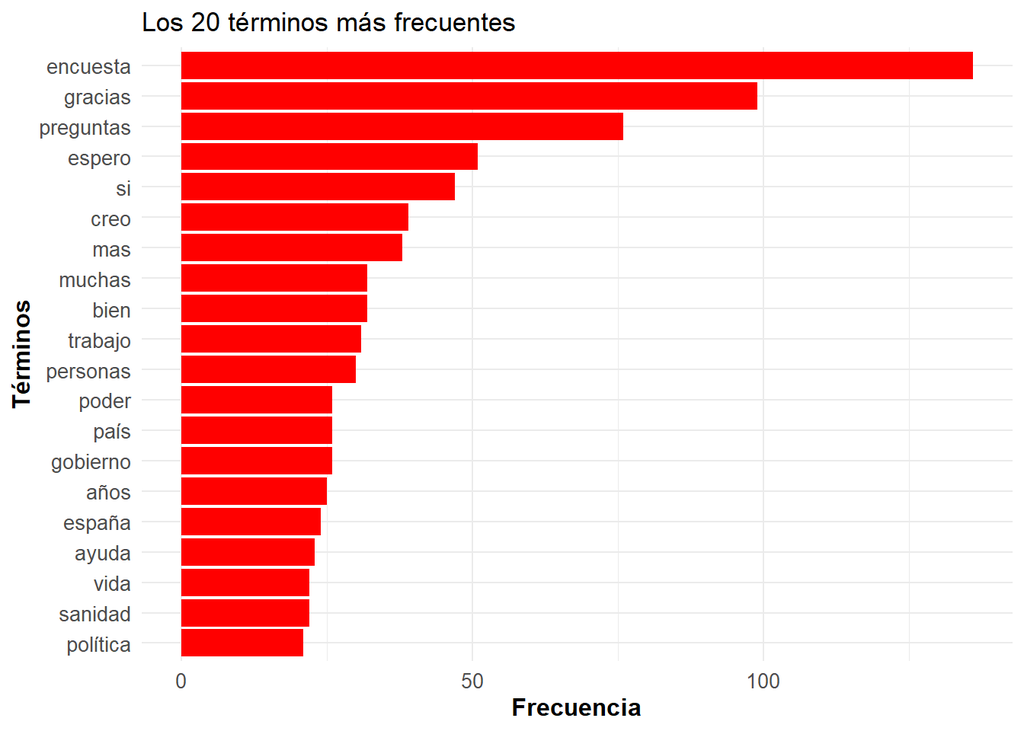

```r
top_20 <- textstat_frequency(dtm_datos, n = 20)

ggplot(top_20, aes(x = reorder(feature, frequency), y = frequency)) +
  geom_col(fill = "red") +
  coord_flip() +
  labs(title = "Los 20 términos más frecuentes",
       x = "Términos",
       y = "Frecuencia") +
  theme_minimal() +
  theme(axis.text = element_text(size = 10),
        axis.title = element_text(size = 12, face = "bold"))
```

Wordcloud

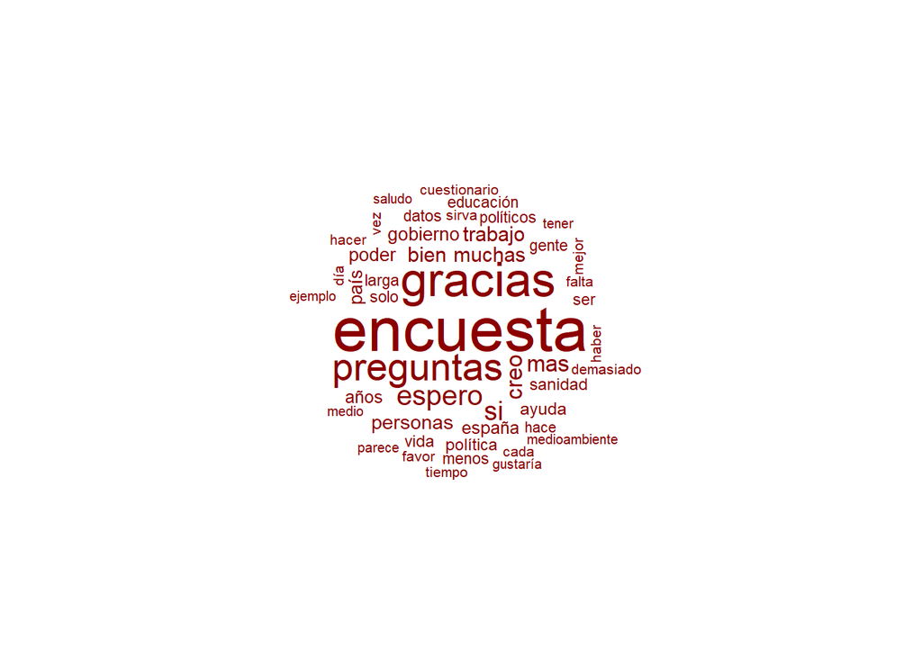

```r
textplot_wordcloud(dtm_datos,
                   color="darkred", min_count = 15) # Palabra que aparecen más de 5 veces
```

### *N-gramas*

Bigramas

```r
bigramasTidy <- datos %>%
  unnest_tokens(bigram, RESPUESTA, token="ngrams",n=2) %>%
  filter(!is.na(bigram))
```

```r
#frecuencias
bigramasTidy %>%
  count(bigram, sort = TRUE) %>% head(n=20)
```

```
          bigram  n
1          de la 47
2    la encuesta 45
3       creo que 37
4     espero que 36
5          en la 34
6         lo que 34
7          no se 34
8         que se 32
9         de las 28
10         en el 27
11   gracias por 27
12          y no 26
13        que no 24
14          a la 23
15        por la 22
16 esta encuesta 21
17 las preguntas 20
18         no me 19
19        que es 19
20        que la 19
```

Lo que se observa NO aporta ningún tipo de información prácticamente ya que son preposiciones junto a artículos, etc.

```r
bigramas_separa <- bigramasTidy %>%
  separate(bigram, c("palabra1", "palabra2"), sep = " ")

bigramas_separa %>%
  count(palabra1,palabra2, sort = TRUE) %>%
  head(n=20)
```

```
   palabra1  palabra2  n
1        de        la 47
2        la  encuesta 45
3      creo       que 37
4    espero       que 36
5        en        la 34
6        lo       que 34
7        no        se 34
8       que        se 32
9        de       las 28
10       en        el 27
11  gracias       por 27
12        y        no 26
13      que        no 24
14        a        la 23
15      por        la 22
16     esta  encuesta 21
17      las preguntas 20
18       no        me 19
19      que        es 19
20      que        la 19
```

Tener en cuenta que hay que cargar las palabras del diccionario de tidytext en español. Paquete TIDYTEXT

```r
bigramas_filtrado <- bigramas_separa %>%
  filter(!palabra1 %in% get_stopwords(language = "es")$word) %>%
  filter(!palabra2 %in% get_stopwords(language = "es")$word)

# Volvemos a ver frec
bi_fil_10 <- bigramas_filtrado %>%
  count(palabra1, palabra2, sort = TRUE) %>%
  head(10)

reactable::reactable(bi_fil_10,
                     fullWidth = F)
```

| palabra1 | palabra2 | n |
| --- | --- | --- |
| muchas | gracias | 16 |
| medio | ambiente | 12 |
| cada | vez | 8 |
| demasiado | larga | 6 |
| hace | falta | 6 |
| encuesta | demasiado | 5 |
| muchas | preguntas | 5 |
| sanidad | pública | 5 |
| demasiadas | preguntas | 4 |
| muchas | cosas | 4 |

```r
bigramas_con_stopwords <- bigramas_filtrado %>%
  unite(bigram,palabra1,palabra2,sep=" ")

bigramas_con_stopwords %>% select(bigram)%>% count(bigram, sort = TRUE) %>% head(10)
```

```
                 bigram  n
1        muchas gracias 16
2        medio ambiente 12
3              cada vez  8
4       demasiado larga  6
5            hace falta  6
6    encuesta demasiado  5
7      muchas preguntas  5
8       sanidad pública  5
9  demasiadas preguntas  4
10         muchas cosas  4
```

Veamos varios ejemplos:

```r
bigramas_filtrado %>%
  filter(palabra2 == "encuesta") %>%
  count(palabra1, sort = TRUE)
```

```
    palabra1 n
1      dicha 3
2   realicen 2
3   realizar 2
4         as 1
5      buena 1
6  contestar 1
7     famosa 1
8    futuros 1
9      hacer 1
10      hizo 1
11  larga.la 1
12       mas 1
13    nuevas 1
14   tercera 1
15    varias 1
```

¿Qué palabras suelen anteceder a la palabra “gracias”?

```r
bigramas_filtrado %>%
  filter(palabra2 == "gracias") %>%
  count(palabra1, sort = TRUE) %>% head(10)
```

```
        palabra1  n
1         muchas 16
2            mil  2
3          ayuda  1
4         ayudas  1
5           bien  1
6  concretamente  1
7         crecer  1
8            doy  1
9            ect  1
10      encuesta  1
```

Asimismo, también se podría combinar los bigramas con la ponderación tf_idf.

```r
bigrama_tf_idf <- bigramas_con_stopwords %>%
  count(datosID,bigram) %>%
  bind_tf_idf(bigram, datosID, n) %>%
  arrange(desc(tf_idf))

bigrama_tf_idf %>% arrange(desc(tf_idf)) %>% head(10)
```

```
   datosID              bigram n tf      idf   tf_idf
1       16 encuesta demuestran 1  1 6.033086 6.033086
2       19  hacerme participar 1  1 6.033086 6.033086
3       32   sentía manipulada 1  1 6.033086 6.033086
4       41         pueda sabar 1  1 6.033086 6.033086
5       42  contribución ayude 1  1 6.033086 6.033086
6       50  manera responsable 1  1 6.033086 6.033086
7       57       veces siempre 1  1 6.033086 6.033086
8       66        salario base 1  1 6.033086 6.033086
9       85       forma curiosa 1  1 6.033086 6.033086
10     101     famosa encuesta 1  1 6.033086 6.033086
```

Ahora se pueden obervar otras palabras que toman especial relevancia.

Trigramas

```r
trigramasTidy <- datos %>% unnest_tokens(trigram, RESPUESTA, token="ngrams",n=3) %>%
  filter(!is.na(trigram))

# Frecuencias
trigramasTidy %>%
  count(trigram, sort = TRUE) %>% head(n=10)
```

```
             trigram n
1       este tipo de 9
2   espero que sirva 8
3    me gustaría que 8
4   tipo de encuesta 8
5     de la encuesta 7
6          de lo que 7
7  el medio ambiente 7
8    sirva para algo 7
9   de esta encuesta 6
10   de las personas 6
```

```r
trigramas_separa <- trigramasTidy %>%
  separate(trigram, c("palabra1", "palabra2","palabra3"), sep = " ")
```

```r
trigramas_filtrado <- trigramas_separa %>%
  filter(!palabra1 %in% get_stopwords(language = "es")$word) %>%
  filter(!palabra2 %in% get_stopwords(language = "es")$word) %>%
  filter(!palabra3 %in% get_stopwords(language = "es")$word)

# Volvemos a ver frec

trigramas_filtrado$palabra1 <- gsub("[0-9[:punct:]]", " ", trigramas_filtrado$palabra1) # Eliminar números de las columnas
trigramas_filtrado$palabra2 <- gsub("[0-9[:punct:]]", " ", trigramas_filtrado$palabra2) # Eliminar números de las columnas
trigramas_filtrado$palabra3 <- gsub("[0-9[:punct:]]", " ", trigramas_filtrado$palabra3) # Eliminar números de las columnas

trigramas_filtrado <- trigramas_filtrado[apply(trigramas_filtrado, 1, function(row) !any(grepl("\\s", row))), , drop = FALSE] # Eliminar aquellas rows ue tengan un whitespace

tri_fil_10 <- trigramas_filtrado %>%
  count(palabra1, palabra2, palabra3, sort = TRUE) %>%
  head(10)

reactable::reactable(tri_fil_10, columns = list(
  palabra1 = reactable::colDef(width = 150),
  palabra1 = reactable::colDef(width = 150),
  palabra1 = reactable::colDef(width = 150),
  n = reactable::colDef(width = 50)),
  fullWidth = F)
```

| palabra1 | palabra2 | palabra3 | n |
| --- | --- | --- | --- |
| encuesta | demasiado | larga | 2 |
| hacer | ningún | comentario | 2 |
| aber | contestado | mediana | 1 |
| absoluta | pues | nadie | 1 |
| absoluta | vergüenza | ejemplares | 1 |
| actual | cada | vez | 1 |
| actual | paronama | político | 1 |
| administración | debe | corregir | 1 |
| administrativos | seguridad | social | 1 |
| adulto | mayor | cumplire | 1 |

```r
trigramas_con_stopwords <- trigramas_filtrado %>%
  unite(trigram,palabra1,palabra2,palabra3,sep=" ")

trigramas_con_stopwords %>% select(trigram)%>% count(trigram,sort = TRUE) %>% head(10)
```

```
                            trigram n
1          encuesta demasiado larga 2
2           hacer ningún comentario 2
3           aber contestado mediana 1
4               absoluta pues nadie 1
5     absoluta vergüenza ejemplares 1
6                   actual cada vez 1
7          actual paronama político 1
8      administración debe corregir 1
9  administrativos seguridad social 1
10            adulto mayor cumplire 1
```

```r
trigramas_con_stopwords %>% select(trigram)%>% count(trigram,sort = TRUE) %>% tail(10)
```

```
                          trigram n
455               ver si servicio 1
456 vergüenza ejemplares antiguos 1
457         verlos crecer gracias 1
458        very interesting servy 1
459               vida mas cuesta 1
460              vida social ocio 1
461             vista ahora mismo 1
462 vivienda alquileres altísimos 1
463                 vote eh bildu 1
464   voto resida individualmente 1
```

En trigramas se observa que posiblemente la gente considera que se hacen encuestas demasiado largas

### **KWIC**

```r
corpus_datos %>% kwic(pattern="encuesta")
```

```
Keyword-in-context with 136 matches.
   [4, 20]                     que no aparece en la | encuesta |
    [9, 8]         placer haber participado en esta | encuesta |
  [13, 10]                  en los resultados de as | encuesta |
  [14, 15]                    que se describe en la | encuesta |
   [16, 4]                                  : ) las | encuesta |
   [16, 8]          las encuesta demuestran que las | encuesta |
   [19, 7]           por hacerme participar en esta | encuesta |
   [25, 2]                                       la | encuesta |
   [26, 9]          bono cultural tras rellenar las | encuesta |
  [27, 13]          minutos que llevo rellenando la | encuesta |
  [38, 24]                 no me incluyan en nuevas | encuesta |
   [41, 4]                             muy buena la | encuesta |
   [46, 4]                          rogaría que las | encuesta |
   [54, 7]                 parece bien este tipo de | encuesta |
  [55, 14]              os merecéis por redactar la | encuesta |
   [57, 4]                            respecto a la | encuesta |
   [62, 5]                          dado que es una | encuesta |
   [64, 5]                        se hace pesada la | encuesta |
  [65, 21]                   ; podrían decir que la | encuesta |
   [67, 6]                comentar que este tipo de | encuesta |
   [73, 2]                                       la | encuesta |
   [74, 5]                           lo malo de las | encuesta |
   [77, 8]          los resultados globales de esta | encuesta |
  [78, 10]            publican los resultados de la | encuesta |
  [79, 16]                     que dicen ( según la | encuesta |
  [82, 14]               : ha realizado antes otras | encuesta |
  [82, 20]                        ? si se refiere a | encuesta |
  [82, 42]                 sí, he respondido varias | encuesta |
   [94, 4]                         no manipuléis la | encuesta |
   [96, 1]                                          | encuesta |
   [96, 8]                     larga. es la tercera | encuesta |
  [96, 25]                dudo del anonimato de las | encuesta |
 [100, 29]                    total y nadie me hizo | encuesta |
 [100, 42]                50 años. sugerencia hacer | encuesta |
  [101, 8]              he participado en la famosa | encuesta |
  [104, 4]                       ojalá pasarán está | encuesta |
  [109, 7]                 de haber podido hacer la | encuesta |
 [110, 10]          por haberme seleccionado a esta | encuesta |
  [112, 7]          parece interesante este tipo de | encuesta |
```

[output cut: 218 more lines]

```
 , lastima que en preocupaciones
 un tanto extensa
 ( gracias )
 está bien aunque es muy
 efectivamente ayudaran a mejorar nuestra
 por la indignacion de privar
 , me ha sido sencilla
 , pienso que es necesario
 es larga por lo menos
 me llega a casa el
 .
 del cis - no son
 del cis, no manden
 y tengo 76 años
 más a menudo
```

```r
kwic_ej <- corpus_datos %>%
  tokens(remove_punct=TRUE,remove_numbers =TRUE,remove_symbols = TRUE, remove_url = TRUE) %>%
  tokens_tolower() %>%
  kwic(pattern="encuesta") %>%
  head(10)
kwic_ej <- as.data.frame(kwic_ej)

kwic_ej2 <- kwic_ej[,-c(1:3,7)]

reactable::reactable(kwic_ej2)
```

| pre | keyword | post |
| --- | --- | --- |
| que no aparece en la | encuesta | además de cuidar la sanidad |
| placer haber participado en esta | encuesta |  |
| en los resultados de as | encuesta | mi total descacuerdo con la |
| que se describe en la | encuesta |  |
| las | encuesta | demuestran que las encuesta no |
| las encuesta demuestran que las | encuesta | no sirven para casi nada |
| por hacerme participar en esta | encuesta |  |
| la | encuesta | es demasiado extensa |
| bono cultural tras rellenar las | encuesta | no un imán |
| minutos que llevo rellenando la | encuesta |  |

### STEMMING y LEMATIZACIÓN

NO SE HA HECHO NI STEMMING NI LEMATIZACIÓN

## Estructura de los datos

### PONDERACIONES Y TRIMMING

En primer lugar, dado que se está realizando un análisis en documentos tan breves como son REGISTROS DE RESPUESTAS ABIERTAS, se encuentra mucho ruido, es decir, palabras especificas de un REGISTRO. Por lo tanto, al igual que en el pre-procesamiento se había tratado términos informativo que son muy generales (stopwords), ahora se tratan también estos términos idiosincráticos antes de aplicar las ponderaciones.

```r
dtm_trimmed <- dtm_datos %>% dfm_trim(min_termfreq = 2,
                                max_termfreq = NULL,
                                min_docfreq = NULL,
                                max_docfreq = NULL)
```

### Ponderación Local

```r
# Proporcional
(dtm_prop <- dtm_trimmed %>%
   dfm_weight(scheme = "prop"))
```

```
Document-feature matrix of: 553 documents, 765 features (99.14% sparse) and 0 docvars.
    features
docs   trabajar   gobierno     subida    precios alimentación    quieren
   1 0.06666667 0.06666667 0.06666667 0.06666667   0.06666667 0.06666667
   2 0          0          0          0            0          0
   3 0          0          0          0            0          0
   4 0          0          0          0            0          0
   5 0          0          0          0            0          0
   6 0          0          0          0            0          0
    features
docs    obtener      costa     pueblo  considero
   1 0.06666667 0.06666667 0.06666667 0.06666667
   2 0          0          0          0
   3 0          0          0          0
   4 0          0          0          0
   5 0          0          0          0
   6 0          0          0          0
[ reached max_ndoc ... 547 more documents, reached max_nfeat ... 755 more features ]
```

```r
# Logaritmica
(dtm_log <-dtm_trimmed %>%
  dfm_weight(scheme = "logcount",base=exp(1)))
```

```
Document-feature matrix of: 553 documents, 765 features (99.14% sparse) and 0 docvars.
    features
docs trabajar gobierno subida precios alimentación quieren obtener costa pueblo
   1        1        1      1       1            1       1       1     1      1
   2        0        0      0       0            0       0       0     0      0
   3        0        0      0       0            0       0       0     0      0
   4        0        0      0       0            0       0       0     0      0
   5        0        0      0       0            0       0       0     0      0
   6        0        0      0       0            0       0       0     0      0
    features
docs considero
   1         1
   2         0
   3         0
   4         0
   5         0
   6         0
[ reached max_ndoc ... 547 more documents, reached max_nfeat ... 755 more features ]
```

A continuación, se utiliza la ponderación TF-IDF (Term Frequency-Inverse Document Frequency).

```r
# Frecuencia inversa
(dtm_tfidf <- dtm_trimmed %>%
  dfm_tfidf())
```

```
Document-feature matrix of: 553 documents, 765 features (99.14% sparse) and 0 docvars.
    features
docs trabajar gobierno   subida  precios alimentación  quieren  obtener
   1 1.663544 1.362514 2.140665 1.839635     2.441695 2.043755 2.441695
   2 0        0        0        0            0        0        0
   3 0        0        0        0            0        0        0
   4 0        0        0        0            0        0        0
   5 0        0        0        0            0        0        0
   6 0        0        0        0            0        0        0
    features
docs    costa   pueblo considero
   1 2.441695 2.265604  1.839635
   2 0        0         0
   3 0        0         0
   4 0        0         0
   5 0        0         0
   6 0        0         0
[ reached max_ndoc ... 547 more documents, reached max_nfeat ... 755 more features ]
```

### Ponderación Global

```r
(dtm_tfidf2 <- dtm_trimmed %>%
  dfm_tfidf(scheme_tf = "prop"))
```

```
Document-feature matrix of: 553 documents, 765 features (99.14% sparse) and 0 docvars.
    features
docs  trabajar   gobierno   subida   precios alimentación   quieren   obtener
   1 0.1109029 0.09083426 0.142711 0.1226423    0.1627797 0.1362503 0.1627797
   2 0         0          0        0            0         0         0
   3 0         0          0        0            0         0         0
   4 0         0          0        0            0         0         0
   5 0         0          0        0            0         0         0
   6 0         0          0        0            0         0         0
    features
docs     costa    pueblo considero
   1 0.1627797 0.1510403 0.1226423
   2 0         0         0
   3 0         0         0
   4 0         0         0
   5 0         0         0
   6 0         0         0
[ reached max_ndoc ... 547 more documents, reached max_nfeat ... 755 more features ]
```

A continuación, se puede observar como han variado los pesos que tienen los términos en la DTM según usando la ponderación tf_idf

```r
# Top ten features con mayor valor para tf_idf
pacman::p_load(tidyr)

pesos <- dtm_tfidf2 %>%
  convert(to="data.frame") %>%
  gather(key = "feature", value = "tfidf", -doc_id) %>%
  arrange(desc(tfidf)) %>%
  head(10)

reactable::reactable(pesos,
  defaultColDef = reactable::colDef(format = reactable::colFormat(separators = TRUE,digits = 2)), fullWidth = F)
```

| doc_id | feature | tfidf |
| --- | --- | --- |
| 5 | hola | 2.44169513564072 |
| 71 | atiende | 2.44169513564072 |
| 260 | disposición | 2.44169513564072 |
| 477 | hacerla | 2.44169513564072 |
| 315 | abril | 2.44169513564072 |
| 540 | digan | 2.44169513564072 |
| 544 | planeta | 2.44169513564072 |
| 425 | placer | 2.26560387658504 |
| 80 | correcto | 2.26560387658504 |
| 95 | luego | 2.26560387658504 |

Los términos con mayor peso son “hola”, “atiende”, “disposición”, “hacerla”, **“abril”**, “digan”, “planeta” entre otros.

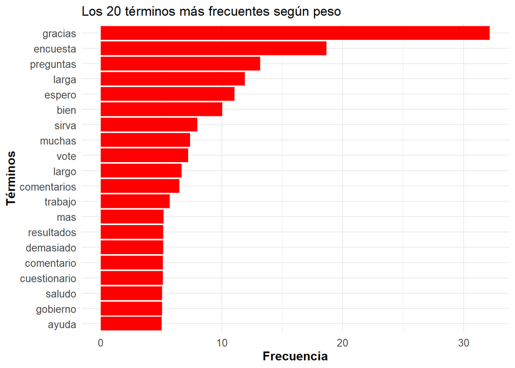

```r
top_20 <- textstat_frequency(dtm_tfidf2,n=20,force=TRUE)

ggplot(top_20, aes(x = reorder(feature, frequency), y = frequency)) +
  geom_col(fill = "red") +
  coord_flip() +
  labs(title = "Los 20 términos más frecuentes según peso",
       x = "Términos",
       y = "Frecuencia") +
  theme_minimal() +
  theme(axis.text = element_text(size = 10),
        axis.title = element_text(size = 12, face = "bold"))
```

## Visualizaciones y analítica descriptiva

### CORRELACIÓN

```r
corr_dtm <- dfm_weight(dtm_datos, scheme = "prop") %>%
  textstat_simil(y = dtm_datos[, c("demasiado", "gracias")], method = "correlation", margin = "features") %>%
  as.data.frame()

demasiado_cor <- corr_dtm %>% filter(feature2=="demasiado") %>%  arrange(-correlation) %>% head(5)

reactable::reactable(demasiado_cor,
  defaultColDef = reactable::colDef(format = reactable::colFormat(separators = TRUE,digits = 2)), fullWidth = F)
```

| feature1 | feature2 | correlation |
| --- | --- | --- |
| reparo | demasiado | 0.47110299928095 |
| impresión | demasiado | 0.47110299928095 |
| indagan | demasiado | 0.47110299928095 |
| privada | demasiado | 0.44498264977506 |
| escala | demasiado | 0.28449319473118 |

```r
grac_cor <- corr_dtm %>% filter(feature2=="gracias") %>%  arrange(-correlation) %>% head(5)

reactable::reactable(grac_cor,columns = list(
  feature1 = reactable::colDef(width = 150)),
  defaultColDef = reactable::colDef(format = reactable::colFormat(separators = TRUE,digits = 2)), fullWidth = F)
```

| feature1 | feature2 | correlation |
| --- | --- | --- |
| muchas | gracias | 0.28358676136054 |
| parado | gracias | 0.19737050059621 |
| duración | gracias | 0.19737050059621 |
| cumplidos | gracias | 0.19737050059621 |
| prácticamente | gracias | 0.19737050059621 |

Orden correlación por encima

```r
corr_dtm %>% filter(correlation > 0.36) %>% arrange(desc(correlation))
```

```
   feature1  feature2 correlation
1    reparo demasiado   0.4711030
2 impresión demasiado   0.4711030
3   indagan demasiado   0.4711030
4   privada demasiado   0.4449826
```

Orden correlación por debajo

```r
corr_dtm %>% filter(correlation < -0.09) %>% arrange(correlation)
```

```
   feature1 feature2 correlation
1 preguntas  gracias -0.09764537
```

### **SIMILITUD COSENO**

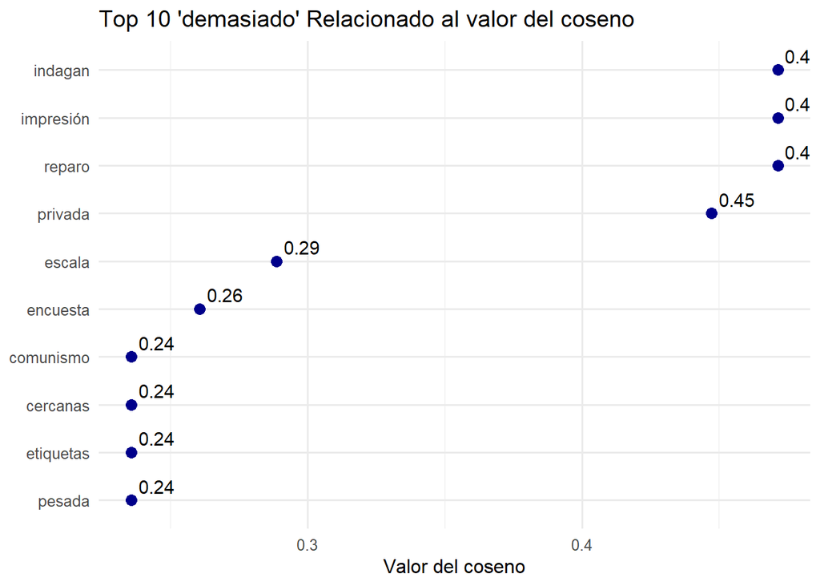

```r
cos_dtm <- dfm_weight(dtm_datos, scheme = "prop") %>%
  textstat_simil(y = dtm_datos[, c("gracias", "demasiado")], method = "cosine", margin = "features") %>%
  as.data.frame()

cos_dtm %>%
  filter(feature2 == "demasiado") %>%
  arrange(-cosine) %>%
  head(n = 10) %>%
  ggplot(aes(y = reorder(feature1, cosine), x = cosine)) +
  geom_point(size = 3, color = "darkblue", shape = 16) +
  geom_text(aes(label = round(cosine, 2)), color = "black", vjust = -0.5, size = 4, hjust = -0.2) +
  labs(title = "Top 10 'demasiado' Relacionado al valor del coseno",
       x = "Valor del coseno",
       y = "") +
  theme_minimal(base_size = 12) +
  theme(axis.title.y = element_blank())
```

```r
cos_dtm %>% filter(cosine>0.35) %>% arrange(desc(cosine))
```

```
   feature1  feature2    cosine
1    reparo demasiado 0.4714045
2 impresión demasiado 0.4714045
3   indagan demasiado 0.4714045
4   privada demasiado 0.4472136
```

### **Análisis de términos relevantes (keyness)**

No se ha realizado

### **Gráfico de dispersión léxica**

P.e., ¿En qué documentos del corpus (y dónde) aparece el término gobierno?

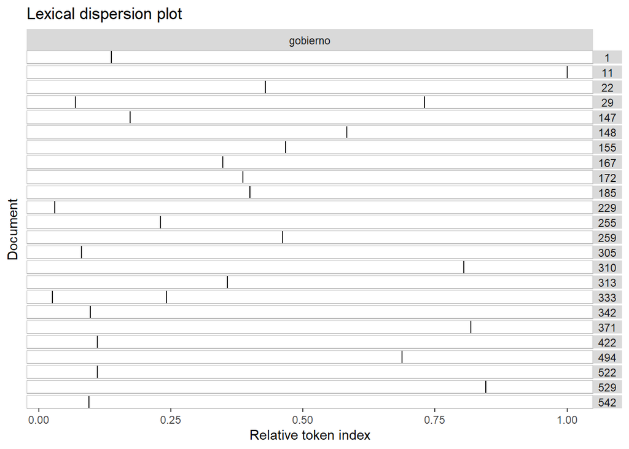

```r
kwic(corpus_datos,pattern="gobierno") %>% textplot_xray()
```

### **Matriz co-ocurrencia de términos**

En primer lugar, se construye la matriz de coocurrencia de términos a partir de la DTM. No obstante, se debe recortar la DTM, en caso contrario la matriz de coocurrencias será excesivamente grande.

```r
dtm_trim <- dfm_trim(dtm_datos, min_termfreq = 5,max_docfreq = 100)
```

Se observan los términos más frecuentes

```r
topfeatures(dtm_trim)
```

```
  gracias preguntas    espero        si      creo       mas    muchas      bien
       99        76        51        47        39        38        32        32
  trabajo  personas
       31        30
```

Seguidamente, se construye la matriz de co-ocurrencia de términos (funcion fcm).

```r
(cooc_delta <- fcm(dtm_trim))
```

```
Feature co-occurrence matrix of: 210 by 210 features.
            features
features     trabajar gobierno precios quieren considero importante sanidad
  trabajar          3        4       1       2         1          1       4
  gobierno          0        2       4       4         3          1       1
  precios           0        0       5       1         1          3       3
  quieren           0        0       0       0         1          1       1
  considero         0        0       0       0         0          1       3
  importante        0        0       0       0         0          0       2
  sanidad           0        0       0       0         0          0       5
  educación         0        0       0       0         0          0       0
  vote              0        0       0       0         0          0       0
  gracias           0        0       0       0         0          0       0
            features
features     educación vote gracias
  trabajar           6    0       3
  gobierno           1    0       2
  precios            1    0       0
  quieren            1    0       1
  considero          2    0       0
  importante         1    0       2
  sanidad           14    0       3
  educación          7    0       7
  vote               0    0       0
  gracias            0    0       2
[ reached max_feat ... 200 more features, reached max_nfeat ... 200 more features ]
```

Interesante ver educación y sanidad

### **GRAFO**

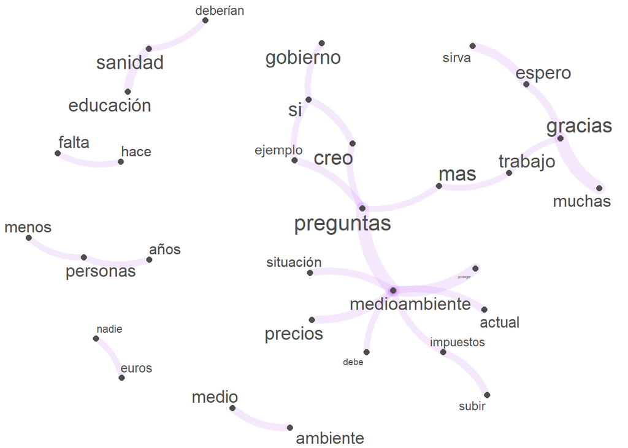

```r
set.seed(134) # útil para mantener el layout en diferentes ejecuciones

textplot_network(cooc_delta,  min_freq = 10,
                 edge_alpha = 0.1,
                 edge_size = 5,
                 edge_color = "purple",
                 vertex_labelsize = log(rowSums(cooc_delta)))
```

```r
rm(list = ls())
```

## Análsisis de sentimientos

Paquetes:

```r
pacman::p_load(haven,sjlabelled,quanteda,ggplot2,dplyr,tidyr,tidytext,textdata,syuzhet,reactable,htmltools,fontawesome)
```

Datos:

```r
datos <- read_sav("Datos.sav")

# Eliminar los labels del nombre de las columnas
datos <- remove_all_labels(datos)
colnames(datos) <- c("REGISTRO", "RESPUESTA")
datos$RESPUESTA <- gsub("\\b(k|q)\\b", "que", datos$RESPUESTA, ignore.case = TRUE)
datos$RESPUESTA <- gsub("\\bencuestas\\b", "encuesta", datos$RESPUESTA, ignore.case = TRUE)
datos$RESPUESTA <- gsub("\\privadas\\b", "privada", datos$RESPUESTA, ignore.case = TRUE)
```

### Análisis de polaridad

Al referirnos a polaridad es si es positivo o negativo

```r
datos <- datos %>% mutate(datosID=row_number()) %>% select(datosID,RESPUESTA,REGISTRO)

tidy_datos <- datos %>%
  unnest_tokens(word,RESPUESTA) %>%
  tibble()
```

Hay que ver la **conveniencia de eliminar las palabras duplicadas del léxico.**

```r
nrc_sp <- get_sentiment_dictionary(dictionary = "nrc",language = "spanish") %>%
  filter(sentiment %in% c("positive","negative")) %>% # Con esto filtramos por polaridad únicamente
  distinct()

nrc_sp$word <- tolower(nrc_sp$word)

lista_duplicados <- nrc_sp %>%
  count(word,sort = TRUE) %>%
  filter(n>1) %>%
  pull(word)

nrc_sp <- nrc_sp %>%
  filter(!word %in% lista_duplicados)
```

Se analiza la polaridad

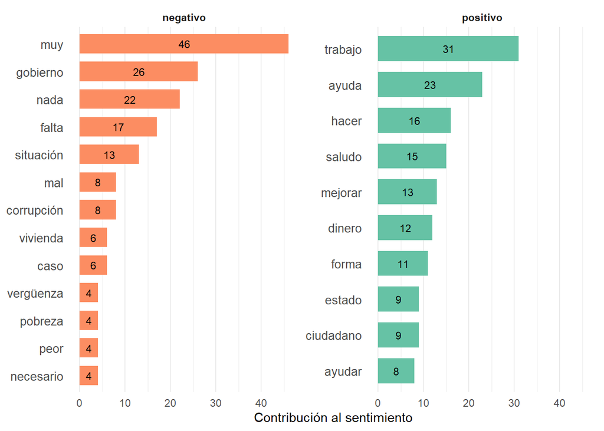

```r
polaridad <- tidy_datos %>%
  inner_join(nrc_sp) %>%
  group_by(datosID,sentiment) %>%
  summarise(total=n())

nrc_sp2 <- nrc_sp

nrc_sp2$sentiment <- gsub("positive", "positivo", nrc_sp2$sentiment)
nrc_sp2$sentiment <- gsub("negative", "negativo", nrc_sp2$sentiment)

tidy_datos %>%
  inner_join(nrc_sp2) %>%
  count(word, sentiment, sort = TRUE) %>%
  ungroup() %>%
  group_by(sentiment) %>%
  slice_max(n, n = 10) %>%
  ungroup() %>%
  mutate(word = reorder(word, n)) %>%
  ggplot(aes(n, word, fill = sentiment, label = n)) +
  geom_col(show.legend = FALSE, width = 0.7) +  # Adjust bar width
  geom_text(position = position_stack(vjust = 0.5), size = 3, color = "black") +  # Add labels to bars
  facet_wrap(~sentiment, scales = "free_y") +
  labs(x = "Contribución al sentimiento",
       y = NULL,
       #title = "Top 10 Words Contributing to Sentiment"
       ) +  # Add title
  scale_fill_brewer(palette = "Set2", direction = -1) +  # Choose a color palette
  theme_minimal() +
  theme(axis.text.y = element_text(size = 10),
        strip.text = element_text(face = "bold"),
        panel.grid.major.y = element_blank(),
        panel.grid.minor.y = element_blank(),
        legend.position = "bottom")  # Position the legend at the bottom
```

```r
polaridad_pivoteado <- polaridad %>%
  pivot_wider(names_from=sentiment,
              values_from = total) # vER SI NO FUNCIONA PORQUE SALEN NAs

polaridad_pivoteado$negative[is.na(polaridad_pivoteado$negative)] <- 0
polaridad_pivoteado$positive[is.na(polaridad_pivoteado$positive)] <- 0
```

```r
nrc_sp2 <- nrc_sp

nrc_sp2$value[nrc_sp2$sentiment == "negative"] <- -1

neg_pos <- tidy_datos %>%
  inner_join(nrc_sp2) %>%
  count(word,value,sort = TRUE) %>% mutate(sentimiento=ifelse(value>0,"positivo","negativo")) %>%
  mutate(total=value*n,cumsum(total)) %>% group_by(sentimiento) %>%
  summarise(suma=sum(total))

total_sum <- sum(neg_pos$suma)

# Create a new row with "Total" in the first column and the sum of values in the second column
new_row <- data.frame(sentimiento = "Total", suma = total_sum)

# Add the new row to the dataframe
neg_pos <- rbind(neg_pos, new_row)

reactable::reactable(neg_pos,
  defaultColDef = reactable::colDef(format = reactable::colFormat(separators = TRUE,digits = 0)), fullWidth = F)
```

| sentimiento | suma |
| --- | --- |
| negativo | -316 |
| positivo | 496 |
| Total | 180 |

Contar número de id

```r
revisiones <- datos %>%
  group_by(datosID) %>%
  count()

polaridad <- inner_join(polaridad_pivoteado,revisiones,by="datosID") # pOLARIDAD TINENE

polaridad$Polaridad <- polaridad$positive - polaridad$negative

polaridad$`Polaridad media` <- round(polaridad$Polaridad / polaridad$n,2)

polaridad$`Polaridad sd` <- round(sqrt(((polaridad$Polaridad - polaridad$`Polaridad media`)^2)/sum(revisiones$n)),2)

polaridad_esp <- polaridad

htmltools::browsable(
  tagList(
    tags$button(
      tagList(fontawesome::fa("download"), "Descargar como CSV"),
      onclick = "Reactable.downloadDataCSV('descargar_tabla1', 'polaridad_esp.csv')"
    ),

  reactable(polaridad_esp,
    pagination=TRUE,
    searchable = TRUE,
    elementId = "descargar_tabla1",

              )
              )
    )
```

| datosID | negative | positive | n | Polaridad | Polaridad media | Polaridad sd |
| --- | --- | --- | --- | --- | --- | --- |
| 1 | 1 | 4 | 1 | 3 | 3 | 0 |
| 4 | 1 | 1 | 1 | 0 | 0 | 0 |
| 6 | 1 | 1 | 1 | 0 | 0 | 0 |
| 7 | 0 | 1 | 1 | 1 | 1 | 0 |
| 8 | 1 | 0 | 1 | -1 | -1 | 0 |
| 10 | 1 | 0 | 1 | -1 | -1 | 0 |
| 11 | 1 | 1 | 1 | 0 | 0 | 0 |
| 13 | 0 | 1 | 1 | 1 | 1 | 0 |
| 15 | 0 | 2 | 1 | 2 | 2 | 0 |
| 16 | 1 | 0 | 1 | -1 | -1 | 0 |

[output cut: 313 more lines]

### NRC en Español

```r
datos <- datos %>%
  unnest_tokens(word,RESPUESTA) %>%
  tibble()
```

```r
nrc_sp2 <- get_sentiment_dictionary(dictionary = "nrc",language = "spanish") %>%
  filter(!sentiment %in% c("positive","negative")) %>% # Con esto filtramos por sentimientos
  distinct()

nrc_sp2$word <- tolower(nrc_sp2$word)

lista_duplicados2 <- nrc_sp2 %>%
  count(word,sort = TRUE) %>%
  filter(n>1) %>%
  pull(word)

nrc_sp2 <- nrc_sp2 %>%
  filter(!word %in% lista_duplicados2)

emociones <- datos %>%
  inner_join(nrc_sp2) %>%
  group_by(datosID,sentiment) %>%
  summarise(total=n())
```

```r
emociones_pivoteado <- emociones %>%
  pivot_wider(names_from=sentiment,
              values_from = total)

emociones_pivoteado_esp <- emociones_pivoteado

colnames(emociones_pivoteado_esp) <- c("datosID", "miedo", "confianza", "asco", "tristeza", "anticipación", "sorpresa", "alegría", "enfado")

htmltools::browsable(
  tagList(
    tags$button(
      tagList(fontawesome::fa("download"), "Descargar como CSV"),
      onclick = "Reactable.downloadDataCSV('descargar_tabla2', 'emociones_pivoteado_esp.csv')"
    ),

  reactable(emociones_pivoteado_esp,
    pagination=TRUE,
    searchable = TRUE,
    elementId = "descargar_tabla2",

              )
              )
    )
```

| datosID | miedo | confianza | asco | tristeza | anticipación | sorpresa | alegría | enfado |
| --- | --- | --- | --- | --- | --- | --- | --- | --- |
| 1 | 1 | 2 | NA | NA | NA | NA | NA | NA |
| 4 | NA | 1 | NA | NA | NA | NA | NA | NA |
| 6 | NA | NA | 1 | NA | NA | NA | NA | NA |
| 9 | NA | 1 | NA | NA | NA | NA | NA | NA |
| 10 | NA | NA | NA | 1 | NA | NA | NA | NA |
| 11 | 1 | NA | NA | NA | NA | NA | NA | NA |
| 13 | NA | 1 | NA | NA | NA | NA | NA | NA |
| 14 | NA | 1 | NA | NA | NA | NA | NA | NA |
| 16 | NA | 2 | NA | 1 | NA | NA | NA | NA |
| 17 | NA | 3 | NA | 1 | NA | NA | NA | NA |

[output cut: 296 more lines]

```r
df_sum <- colSums(emociones_pivoteado_esp[, -1], na.rm = TRUE)

df_sum <- data.frame(
  Emoción = c("Miedo", "Confianza", "Asco", "Tristeza", "Anticipación", "Sorpresa", "Alegría", "Enfado"),
  Valor = c(51, 295, 20, 93, 65, 3, 16, 6)
)

df_sum <- df_sum %>%
  arrange(desc(Valor))


reactable(df_sum)
```

| Emoción | Valor |
| --- | --- |
| Confianza | 295 |
| Tristeza | 93 |
| Anticipación | 65 |
| Miedo | 51 |
| Asco | 20 |
| Alegría | 16 |
| Enfado | 6 |
| Sorpresa | 3 |

```r
reactable::reactable(df_sum,columns = list(
  Emoción = reactable::colDef(width = 125)),
  defaultColDef = reactable::colDef(format = reactable::colFormat(separators = TRUE,digits = 0)), fullWidth = F)
```

| Emoción | Valor |
| --- | --- |
| Confianza | 295 |
| Tristeza | 93 |
| Anticipación | 65 |
| Miedo | 51 |
| Asco | 20 |
| Alegría | 16 |
| Enfado | 6 |
| Sorpresa | 3 |

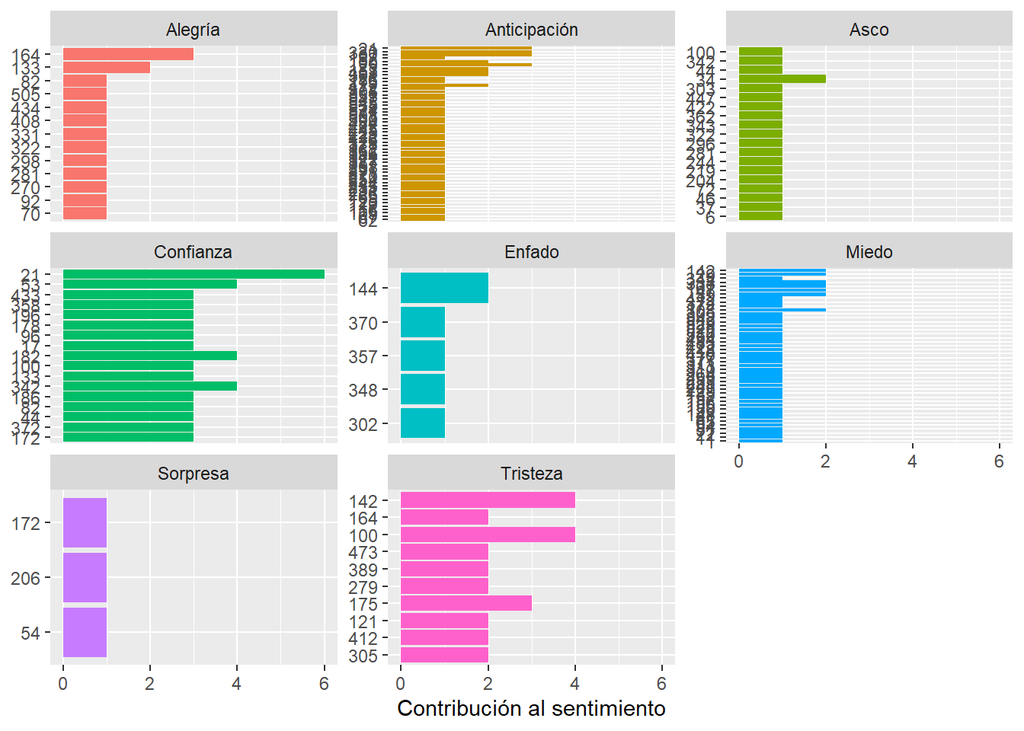

```r
nrc_sp3 <- nrc_sp2

nrc_sp3$sentiment <- gsub("fear", "Miedo", nrc_sp3$sentiment)
nrc_sp3$sentiment <- gsub("trust", "Confianza", nrc_sp3$sentiment)
nrc_sp3$sentiment <- gsub("disgust", "Asco", nrc_sp3$sentiment)
nrc_sp3$sentiment <- gsub("sadness", "Tristeza", nrc_sp3$sentiment)
nrc_sp3$sentiment <- gsub("anticipation", "Anticipación", nrc_sp3$sentiment)
nrc_sp3$sentiment <- gsub("surprise", "Sorpresa", nrc_sp3$sentiment)
nrc_sp3$sentiment <- gsub("joy", "Alegría", nrc_sp3$sentiment)
nrc_sp3$sentiment <- gsub("anger", "Enfado", nrc_sp3$sentiment)

tidy_datos %>%
  inner_join(nrc_sp3) %>%
  count(datosID,sentiment,sort=TRUE) %>%
  ungroup() %>%
  group_by(sentiment) %>%
  slice_max(n, n = 10) %>%
  ungroup() %>%
  mutate(datosID = reorder(datosID, n)) %>%
  ggplot(aes(n, datosID, fill = sentiment)) +
  geom_col(show.legend = FALSE) +
  facet_wrap(~sentiment, scales = "free_y") +
  labs(x = "Contribución al sentimiento",
       y = NULL)
```

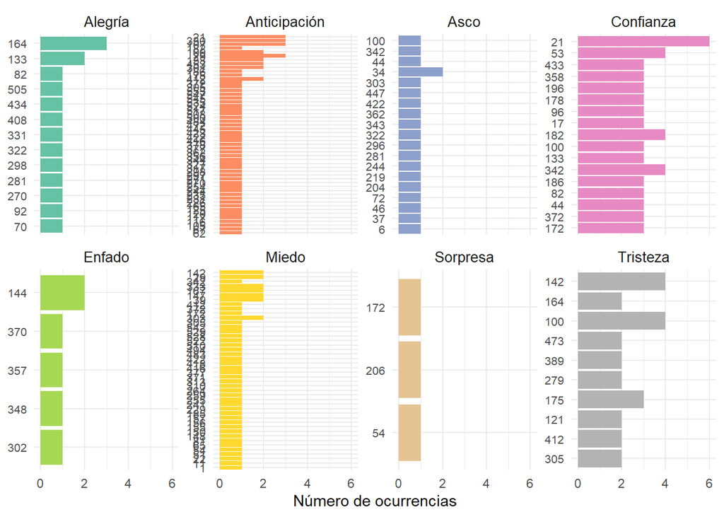

```r
tidy_datos %>%
  inner_join(nrc_sp3) %>%
  count(datosID, sentiment, sort = TRUE) %>%
  ungroup() %>%
  group_by(sentiment) %>%
  slice_max(n, n = 10) %>%
  ungroup() %>%
  mutate(datosID = reorder(datosID, n)) %>%
  ggplot(aes(x = n, y = datosID, fill = sentiment)) +
  geom_col(show.legend = FALSE) +
  facet_wrap(~ sentiment, scales = "free_y", nrow = 2) +
  scale_fill_brewer(palette = "Set2") +  # Use a different color palette
  labs(x = "Número de ocurrencias",  # Adjusted x-axis label
       y = NULL,  # No y-axis label
       #title = "Top 10 Contribuciones al Sentimiento por Categoría Emocional",  # Added title
) +  # Added caption
  theme_minimal() +  # Minimalist theme
  theme(plot.title = element_text(size = 14, hjust = 0.5, face = "bold"),  # Adjust title size and alignment
        plot.subtitle = element_text(size = 11, hjust = 0.5),  # Adjust subtitle size and alignment
        axis.text.y = element_text(size = 8),  # Adjust y-axis text size
        strip.text = element_text(size = 10))  # Adjust facet text size
```

El sentimiento que más se repite es el de CONFIANZA Y TRISTEZA

```r
polaridad_emociones_total <- merge(polaridad, datos, by="datosID", all=TRUE) %>%
  distinct()

polaridad_emociones_total <- inner_join(polaridad_emociones_total,emociones_pivoteado,by="datosID")

polaridad_emociones_total_esp <- polaridad_emociones_total

htmltools::browsable(
  tagList(
    tags$button(
      tagList(fontawesome::fa("download"), "Descargar como CSV"),
      onclick = "Reactable.downloadDataCSV('descargar_tabla3', 'polaridad_emociones_total_esp.csv')"
    ),

  reactable(polaridad_emociones_total_esp,
    pagination=TRUE,
    searchable = TRUE,
    elementId = "descargar_tabla3",

              )
              )
    )
```

| datosID | negative | positive | n | Polaridad | Polaridad media | Polaridad sd | REGISTRO | word | fear | trust | disgust | sadness | anticipation | surprise | joy | anger |
| --- | --- | --- | --- | --- | --- | --- | --- | --- | --- | --- | --- | --- | --- | --- | --- | --- |
| 1 | 1 | 4 | 1 | 3 | 3 | 0 | 47 | subida | 1 | 2 | NA | NA | NA | NA | NA | NA |
| 1 | 1 | 4 | 1 | 3 | 3 | 0 | 47 | a | 1 | 2 | NA | NA | NA | NA | NA | NA |
| 1 | 1 | 4 | 1 | 3 | 3 | 0 | 47 | que | 1 | 2 | NA | NA | NA | NA | NA | NA |
| 1 | 1 | 4 | 1 | 3 | 3 | 0 | 47 | para | 1 | 2 | NA | NA | NA | NA | NA | NA |
| 1 | 1 | 4 | 1 | 3 | 3 | 0 | 47 | de | 1 | 2 | NA | NA | NA | NA | NA | NA |
| 1 | 1 | 4 | 1 | 3 | 3 | 0 | 47 | se | 1 | 2 | NA | NA | NA | NA | NA | NA |
| 1 | 1 | 4 | 1 | 3 | 3 | 0 | 47 | importante | 1 | 2 | NA | NA | NA | NA | NA | NA |
| 1 | 1 | 4 | 1 | 3 | 3 | 0 | 47 | unificar | 1 | 2 | NA | NA | NA | NA | NA | NA |
| 1 | 1 | 4 | 1 | 3 | 3 | 0 | 47 | alimentación | 1 | 2 | NA | NA | NA | NA | NA | NA |
| 1 | 1 | 4 | 1 | 3 | 3 | 0 | 47 | en | 1 | 2 | NA | NA | NA | NA | NA | NA |

[output cut: 6931 more lines]

### AFINN en Español

Hacer lo anterior con el diccionario AFINN traducido desde el español

```r
datos <- read_sav("Datos.sav")

# Eliminar los labels del nombre de las columnas
datos <- remove_all_labels(datos)
colnames(datos) <- c("REGISTRO", "RESPUESTA")
datos$RESPUESTA <- gsub("\\b(k|q)\\b", "que", datos$RESPUESTA, ignore.case = TRUE)
datos$RESPUESTA <- gsub("\\bencuestas\\b", "encuesta", datos$RESPUESTA, ignore.case = TRUE)
datos$RESPUESTA <- gsub("\\privadas\\b", "privada", datos$RESPUESTA, ignore.case = TRUE)

pacman::p_load(readxl)
traduccion_afinn <- read_excel("Traducción_afinn.xlsx")
```

```r
datos <- datos %>% mutate(datosID=row_number()) %>% select(datosID,RESPUESTA,REGISTRO)

tidy_datos <- datos %>%
  unnest_tokens(word,RESPUESTA) %>%
  tibble()
```

Uso de AFINN

B. Polaridad del corpus

La variable value es numérica, acumular el puntaje positivo/negativo

Esto quiere decir que la polaridad global de las respuestas es -151 –> NEGATIVA

Podemos agrupar por valor pos/neg

Ver la polaridad general repartida por positivo y negativo

```r
neg_pos <- tidy_datos %>%
  inner_join(traduccion_afinn) %>%
  count(espanol,value,sort = TRUE) %>% mutate(sentimiento=ifelse(value>0,"positivo","negativo")) %>%
  mutate(total=value*n,cumsum(total)) %>% group_by(sentimiento) %>%
  summarise(suma=sum(total))

total_sum <- sum(neg_pos$suma)

# Create a new row with "Total" in the first column and the sum of values in the second column
new_row <- data.frame(sentimiento = "Total", suma = total_sum)

# Add the new row to the dataframe
neg_pos <- rbind(neg_pos, new_row)

reactable::reactable(neg_pos,
  defaultColDef = reactable::colDef(format = reactable::colFormat(separators = TRUE,digits = 0)), fullWidth = F)
```

| sentimiento | suma |
| --- | --- |
| negativo | -265 |
| positivo | 114 |
| Total | -151 |

C. Evolución polaridad across corpus: medidas por grupos de entrevistas (ver llamada a group_by para cada léxico)

Bloques de 10 comentarios (10 respuestas)

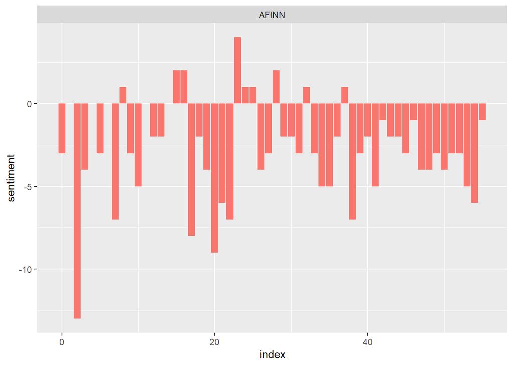

```r
afinn <- tidy_datos %>%
  inner_join(traduccion_afinn) %>%
  group_by(index = datosID %/% 10) %>%  #bloques de 10 tweets
  summarise(sentiment = sum(value)) %>%
  mutate(method = "AFINN")

afinn %>%
  ggplot(aes(index, sentiment, fill = method)) +
  geom_col(show.legend = FALSE) +
  facet_wrap(~method, ncol = 1, scales = "free_y")
```

Bloques de 20 comentarios (20 respuestas)

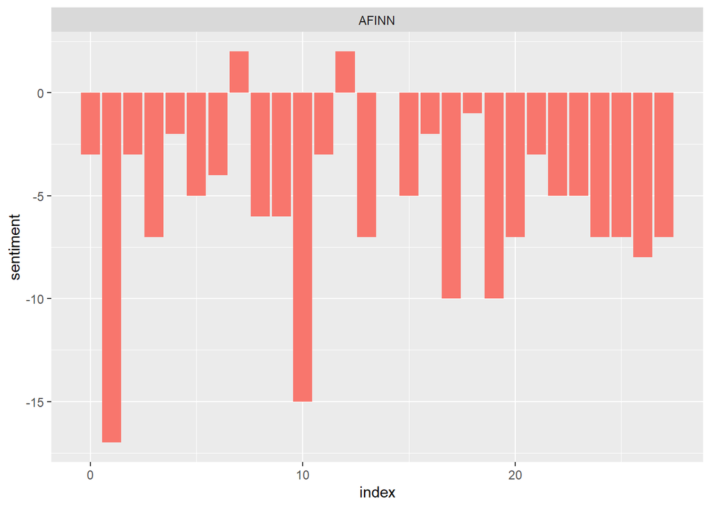

```r
afinn <- tidy_datos %>%
  inner_join(traduccion_afinn) %>%
  group_by(index = datosID %/% 20) %>%  #bloques de 10 tweets
  summarise(sentiment = sum(value)) %>%
  mutate(method = "AFINN")

afinn %>%
  ggplot(aes(index, sentiment, fill = method)) +
  geom_col(show.legend = FALSE) +
  facet_wrap(~method, ncol = 1, scales = "free_y")
```

Bloques de 1 comentario (1 respuesta)

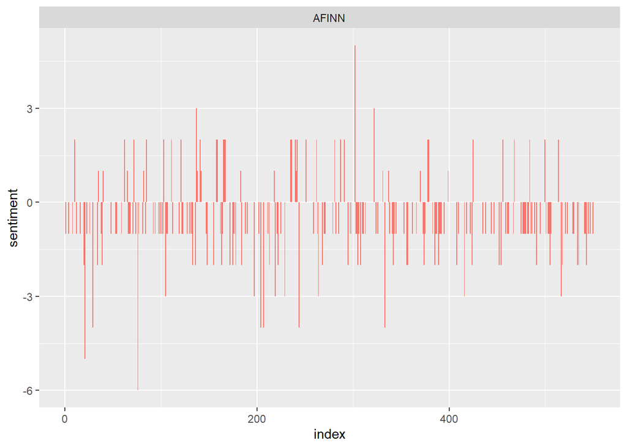

```r
afinn <- tidy_datos %>%
  inner_join(traduccion_afinn) %>%
  group_by(index = datosID %/% 1) %>%  #bloques de 10 tweets
  summarise(sentiment = sum(value)) %>%
  mutate(method = "AFINN")

afinn %>%
  ggplot(aes(index, sentiment, fill = method)) +
  geom_col(show.legend = FALSE) +
  facet_wrap(~method, ncol = 1, scales = "free_y")
```

D. Distribución de polaridad

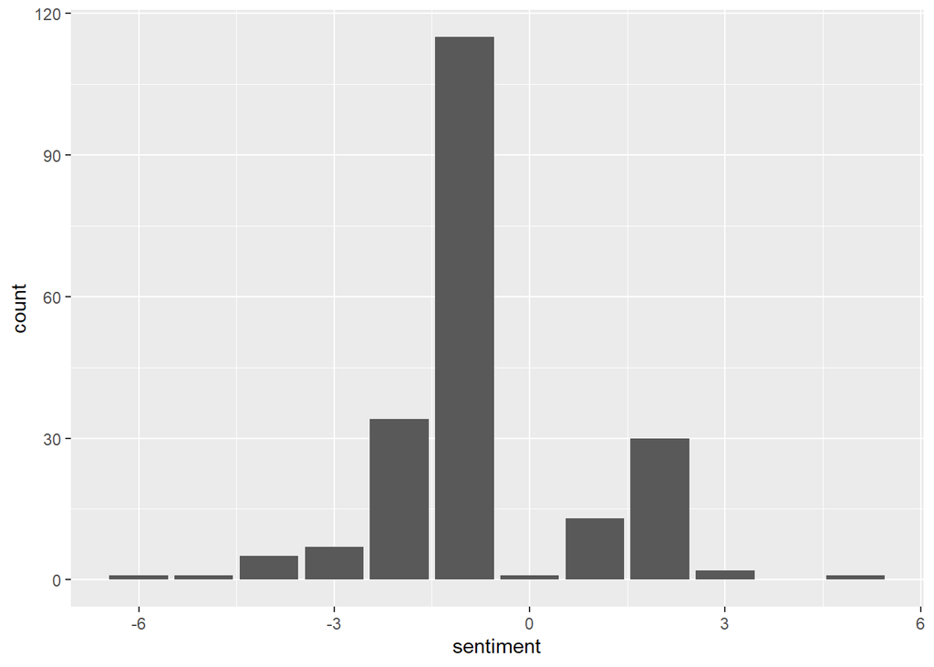

```r
afinn.dist <- tidy_datos %>%
  inner_join(traduccion_afinn) %>%
  group_by(index = datosID ) %>%
  summarise(sentiment = sum(value))

afinn.dist %>% ggplot(aes(x=sentiment)) +
  geom_bar()
```

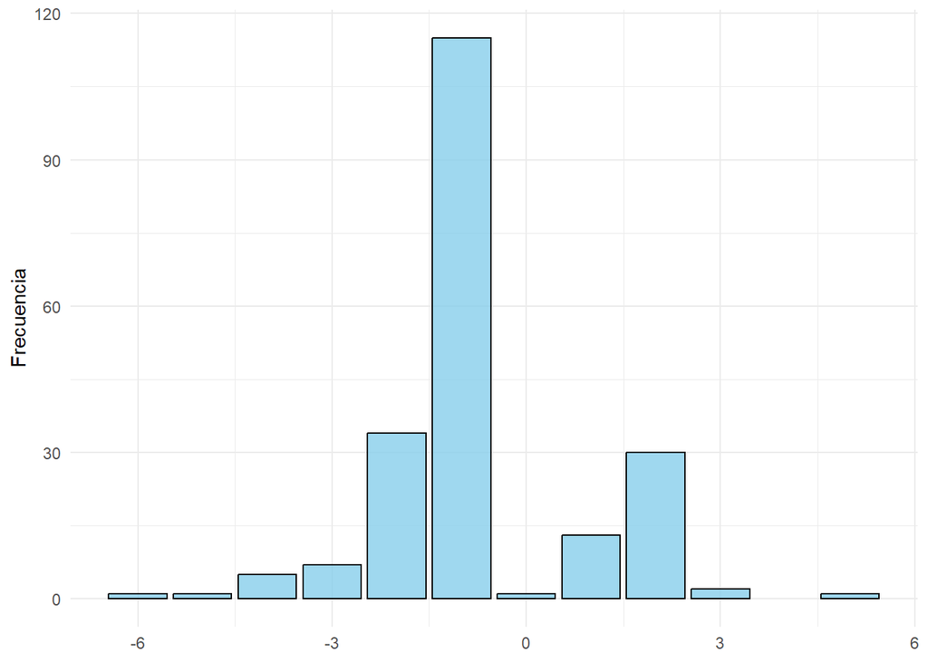

```r
afinn.dist %>%
  ggplot(aes(x = sentiment)) +
  geom_bar(fill = "skyblue", color = "black", alpha = 0.8) +  # Adjust bar appearance
  labs(
    x = NULL,
    y = "Frecuencia",
    title = NULL
  ) +
  theme_minimal()
```

E. Términos positivos/negativos más frecuentes y su contribución al tono de los comentarios

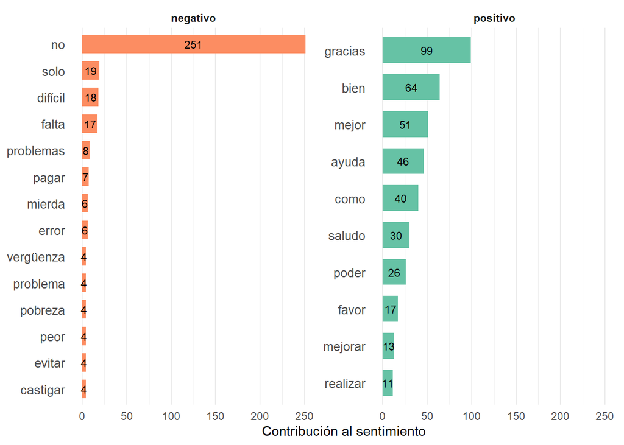

```r
traduccion_afinn$sentiment <- ifelse(traduccion_afinn$value > 0, "positivo", "negativo")
traduccion_afinn <- traduccion_afinn[,-1]
colnames(traduccion_afinn) <- c("value"  ,  "word" ,  "sentiment")

tidy_datos %>%
  inner_join(traduccion_afinn) %>%
  count(word, sentiment, sort = TRUE) %>%
  ungroup() %>%
  group_by(sentiment) %>%
  slice_max(n, n = 10) %>%
  ungroup() %>%
  mutate(word = reorder(word, n)) %>%
  ggplot(aes(n, word, fill = sentiment, label = n)) +
  geom_col(show.legend = FALSE, width = 0.7) +  # Adjust bar width
  geom_text(position = position_stack(vjust = 0.5), size = 3, color = "black") +  # Add labels to bars
  facet_wrap(~sentiment, scales = "free_y") +
  labs(x = "Contribución al sentimiento",
       y = NULL,
       #title = "Top 10 Words Contributing to Sentiment"
       ) +  # Add title
  scale_fill_brewer(palette = "Set2", direction = -1) +  # Choose a color palette
  theme_minimal() +
  theme(axis.text.y = element_text(size = 10),
        strip.text = element_text(face = "bold"),
        panel.grid.major.y = element_blank(),
        panel.grid.minor.y = element_blank(),
        legend.position = "bottom")  # Position the legend at the bottom
```

```r
tidy_datos %>%
  inner_join(traduccion_afinn) %>%
  group_by(datosID) %>%
  summarise(sentimiento=sum(value)) %>%
  left_join(datos)
```

```
# A tibble: 383 × 4
   datosID sentimiento RESPUESTA                                         REGIS…¹
     <int>       <dbl> <chr>                                               <dbl>
 1       1           5 que se ponga a trabajar el gobierno en la subida…      47
 2       3           2 gracias                                                53
 3       4           0 vivo con mi mujer y nos preocupa realmente el pr…      58
 4       6           2 espero sea útil, creo que el número de preguntas…      63
 5       8           1 realmente lo que me preocupa es la subida de pre…      73
 6       9           3 es un placer haber participado en esta encuesta.       81
 7      10           6 nada. ha sido un placer poder ayudarles.               83
 8      11           3 tienen que mejorar la seguridad social el gobier…      89
 9      12          -1 - tanto las preguntas comos las opciones de resp…      98
10      15           0 debería de haber muchos cambios políticos, sueld…     112
# … with 373 more rows, and abbreviated variable name ¹REGISTRO
```

```r
tidy_datos %>%
  inner_join(traduccion_afinn) %>%
  count(word, sentiment, sort = TRUE) %>%
  ungroup() %>%
  group_by(sentiment) %>%
  slice_max(n, n = 10) %>%
  ungroup() %>%
  mutate(word = reorder(word, n))
```

```
# A tibble: 24 × 3
   word      sentiment     n
   <fct>     <chr>     <int>
 1 no        negativo    251
 2 solo      negativo     19
 3 difícil   negativo     18
 4 falta     negativo     17
 5 problemas negativo      8
 6 pagar     negativo      7
 7 error     negativo      6
 8 mierda    negativo      6
 9 castigar  negativo      4
10 evitar    negativo      4
# … with 14 more rows
```

### SENTIMENTR

NO se puede hacer porque es un paquete en inglés y los datos están en español